# TableMt_2012

D. Ackerly, J. Slingsby

February 14, 2016

In 2012, we placed 96 dataloggers recording temperature and humidity across Table Mt. and Silvermine. The loggers were stratified across gradients of elevation, slope, exposure and hillslope position (hilltop, valleybottom), and distance from both False Bay and the Atlantic. In previous analyses, the data has been analyzed to extract diurnal Tmin, Tmax, VPmax (maximum daily vapor pressure), and RHsat.hrs (hours per day with relative humidity above 95%).

In preliminary analyses, we found that during periods of rapidly changing weather, the Tmin for one day might occur at midnight (if the previous night had been warmer) and then another Tmin would be recorded in the early morning of the next day. Similar patterns were observed for Tmax. In order to minimize this problem, we calculated Tmin values for each day in the 24 hours between 1500h the prior day and 1500h on a given day. Similarly, we calculated Tmax in the 24 hours between 0600h on the day in question and 0600h on the following day. The time at which Tmin and Tmax were observed is also recorded, with negative values for Tmin indicating the prior day, and values >24 for Tmax indicating the next day.

Tmin and Tmax may not be observed at the same time at different locations, which may reduce the apparent environmental lapse rates. For a more direct analysis of lapse rates, we also examine temperature at 0600h and 1400h, which are approximately when Tmin and Tmax, respectively, are most often observed. See ‘sandbox/extract-6-14h-temps.R’ for extraction script for those values.

All of these analyses and the summary data are available at: https://github.com/dackerly/table-mt-microclimate-2012.git

General summary statistics about the sites and daily weather values can be found in ‘manuscript-summary-stats.r’.

The goal of these analyses is to examine spatial variation in daily weather values, running models for each day through 2012. The initial question is whether the important spatial variables vary with season, but as shown below a key result is enormous day to day variation in the ability to explain spatial variation in weather variables. I’m still searching for explanations in regional weather or other factors to understand why the models differ so much from day to day.

```r
#----------------#
# LOAD LIBRARIES #
#----------------#
rm(list=ls())
library(raster)
library(RColorBrewer)
```

‘meta’ contains metadata on the 96 sites. ‘topo10’ and ‘topo30’ have a series of topographic features sampled from 10m and 30m dem rasters, respectively, based on lat/long positions of each site. SiteID is the unique name for each site.

Some of the variables in ‘meta’: * elevation, slope, and aspect: measured in the field - these are generally not used, and instead we use a consistent set of values taken from the 10m dem. * use4Analyses, use4ClimateSummaries: sites excluded due to incomplete data (see ms for criteria)

Variables in topo10 and topo30: * d2at, d2fb, d2cs: distance to atlantic, distance to false bay, distance to coast = min(d2at,d2fb) * rad080, rad172, rad355: solar radiation at summer and winter solstice, and equinox. Not generally used as we have diurnal radiation at each site * thl0, thl315, thl337: Topographic heat load as defined by McCune and Keon 2002 JVS, with the axis for calculation of the ‘folded aspect’ (and thus the maximum heat load) at 0, 337 or 315 degrees. The logic is that in the S Hem, NW facing slopes would be hotter than N facing, due to higher afternoon temperatures. * plow050, 125, 250, 500: Percent lower pixels - the percent of pixels surrounding a focal pixel with a lower elevation, in radii of 50, 125, 250 or 500 m. A measure of potential for cold air to flow away from a spot. Higher values indicate hilltops * tpi050, 125, 250, 500: Elevation of a focal pixel - mean elevation in the specified radius. Another measure of hillslope position, with positive values for hilltops, negative for valley bottoms.

```r
#----------------#
# LOAD DATA      #
#----------------#
meta <- read.csv('data/csv_masters/location_meta.csv',as.is=T)
dim(meta)
```

```
## [1] 96 27
```

```r
head(meta)
```

```
##       domain siteID   logger UTM.east UTM.north   LON_DD    LAT_DD
## 1 SILVERMINE   CHK1 10008095   256907   6228779 18.36633 -34.05353
## 2 SILVERMINE   CHK2 10006349   257070   6229153 18.36820 -34.05020
## 3 SILVERMINE   CHK3 10008094   257271   6228903 18.37031 -34.05250
## 4 SILVERMINE   CHK4 10008096   257420   6229224 18.37201 -34.04964
## 5 SILVERMINE   CHK5 10008093   258353   6229582 18.38221 -34.04663
## 6 SILVERMINE   CHK6 10006348   258397   6229772 18.38274 -34.04493
##   elevation slope_deg aspect_deg magn.true.aspect use4Analyses
## 1       120        19        265                M            1
## 2       326         8        350                M            1
## 3       325        32        240                M            1
## 4       367        26        355                M            1
## 5       436        35         15                M            1
## 6       455        33        280                M            1
##   use4ClimateSummaries route CollSeq series deployed.as deployXssn
```

[output cut: 20 more lines]

```r
topo10 <- read.csv('data/csv_masters/topo10.csv',as.is=T)
dim(topo10)
```

```
## [1] 96 22
```

```r
names(topo10)
```

```
##  [1] "siteID"    "domain"    "elevation" "slope"     "aspect"
##  [6] "d2at"      "d2fb"      "d2cs"      "rad080"    "rad172"
## [11] "rad355"    "thl0"      "thl315"    "thl337"    "plow050"
## [16] "plow125"   "plow250"   "plow500"   "tpi050"    "tpi125"
## [21] "tpi250"    "tpi500"
```

```r
topo30 <- read.csv('data/csv_masters/topo30.csv',as.is=T)
dim(topo30)
```

```
## [1] 96 21
```

```r
names(topo30)
```

```
##  [1] "siteID"    "domain"    "elevation" "slope"     "d2at"
##  [6] "d2fb"      "d2cs"      "rad080"    "rad172"    "rad355"
## [11] "thl0"      "thl315"    "thl337"    "plow050"   "plow125"
## [16] "plow250"   "plow500"   "tpi050"    "tpi125"    "tpi250"
## [21] "tpi500"
```

‘dw’ has all daily weather values for all sites and days. The dlySummary contains summaries of weather data on each day - average weather across sites. dlySol has diurnal radiation at each site for each day of the year, from Adam Wilson’s analyses on a 30m dem.

```r
dw <- read.csv('data/csv_masters/2012daily.csv',as.is=T)
head(dw)
```

```
##   doy11 year month day   Tmin Tmin.time   Tmax Tmax.time   Tmean  RHmin
## 1   366 2012     1   1 14.936  6.166667 25.210  17.16667 20.0730 71.361
## 2   366 2012     1   1 13.762  6.166667 27.161  15.00000 20.4615 78.299
## 3   366 2012     1   1 13.233  6.000000 22.776  17.33333 18.0045 83.567
## 4   366 2012     1   1 13.546  6.000000 25.647  15.33333 19.5965 81.918
## 5   366 2012     1   1 12.413  6.000000 22.896  13.83333 17.6545 91.167
## 6   366 2012     1   1 12.727  6.000000 27.014  14.00000 19.8705 84.421
##    RHmax    VPmax RHsat.hrs     date siteID doy    T06    T14
## 1 77.590 2.239716         0 2012-1-1   CHK1   1 14.984 24.968
## 2 82.556 2.267693         0 2012-1-1   CHK2   1 13.882 25.841
## 3 85.799 2.215489         0 2012-1-1   CHK3   1 13.233 22.274
## 4 83.437 2.133584         0 2012-1-1   CHK4   1 13.546 24.436
## 5 87.839 2.011852         0 2012-1-1   CHK5   1 12.413 22.321
## 6 87.179 2.199438         0 2012-1-1   CHK6   1 12.727 27.014
```

```r
dlySummary <- read.csv('data/csv_outfiles/dlySummary.csv',as.is=T)
head(dlySummary)
```

```
##   doy year month day       date     Tmin     Tmax    Tmean   dtRange
## 1   1 2012     1   1 2012-01-01 11.39483 21.62492 16.50988 10.230091
## 2   2 2012     1   2 2012-01-02 14.97574 19.01598 16.99586  4.040239
## 3   3 2012     1   3 2012-01-03 14.75741 23.10118 18.92930  8.343773
## 4   4 2012     1   4 2012-01-04 10.78530 23.34831 17.06680 12.563011
## 5   5 2012     1   5 2012-01-05 13.78350 25.12926 19.45638 11.345761
## 6   6 2012     1   6 2012-01-06 14.36026 27.59257 20.97641 13.232307
##     dt1406    RHmin    RHmax    VPmax RHsat.hrs TminSr TmaxSr   RHsatSr
## 1 8.713648 83.64332 92.68127 1.920619  5.545455 11.897 15.774 17.666667
## 2 3.058227 52.31199 99.71526 1.937674 19.000000  5.775 13.309 14.666667
## 3 7.143943 52.63628 98.78947 1.702166 15.679924  7.611 14.073 24.000000
## 4 9.531773 39.66210 94.06428 1.792897  4.657197 13.317 12.957 13.000000
## 5 9.547602 28.20923 95.26178 1.872311  7.526515  7.701  9.869 14.333333
## 6 8.477261 51.95174 85.88167 2.043691  1.242424  9.235  9.813  7.833333
##     VPmaxSr sommax sommin Kps.mean_hPa Kppt_mm Kwspd.mean_m.s
## 1 0.8270558     16     15        997.0     0.6       2.991667
## 2 0.6197326     15     14        995.5    11.6       2.504167
## 3 0.6384510      7      7        997.2     0.2       2.279167
## 4 0.6167037     11     11        998.2     0.0       2.304167
## 5 0.5638149     11      7        999.6     0.0       1.975000
## 6 0.5298096     11      8        999.4     0.0       2.170833
##   Kwspd.max_m.s
## 1           5.6
## 2           5.4
## 3           4.7
## 4           3.1
## 5           2.7
## 6           4.8
```

```r
dlySol <- readRDS('data/Rdata/dlySol.Rdata')
dlySol[1:6,1:6]
```

```
##      rad_tot_001 rad_tot_002 rad_tot_003 rad_tot_004 rad_tot_005
## CHK1    8663.728    8652.467    8640.090    8626.597    8611.990
## CHK2    9244.997    9240.468    9235.409    9229.817    9223.687
## CHK3    7737.912    7724.081    7708.918    7692.427    7674.611
## CHK4    8369.773    8371.854    8374.001    8376.205    8378.459
## CHK5    8767.362    8767.380    8767.277    8767.045    8766.678
## CHK6    8059.166    8050.924    8041.838    8031.906    8021.127
##      rad_tot_006
## CHK1    8596.270
## CHK2    9217.014
## CHK3    7629.731
## CHK4    8380.751
## CHK5    8766.166
## CHK6    8009.500
```

Before fitting any spatial models of weather variation, we want to check for correlations and spatial autocorrelation of predictors. Based on the topo10 variables, here are all variables with pairwise correlations R2 > 0.5. Commented code can be run to see more detail. As expected, radiation load variables are mostly correlated, and hillslope position variables are correlated. Below, we run alternative models swapping these in and out, but not using them in the same model.

```r
# cor(topo10[,-c(1:2)],use='pair')
# pairs(topo10[,-c(1:2)])
# names(topo10)
#
## find correlations > 0.5
i <- 3; j <- 4;
for (i in 3:(ncol(topo10)-1)) for (j in (i+1):ncol(topo10)) {
    rr <- cor(topo10[,i],topo10[,j],use='pair')
    if (abs(rr)>sqrt(0.5)) print(c(names(topo10)[c(i,j)],round(rr,3)))
}
```

```
## [1] "slope"  "rad355" "-0.746"
## [1] "rad080" "rad172" "0.952"
## [1] "rad080" "thl0"   "0.827"
## [1] "rad080" "thl337" "0.78"
## [1] "rad172" "thl0"   "0.723"
## [1] "thl0"   "thl315" "0.803"
## [1] "thl0"   "thl337" "0.951"
## [1] "thl315" "thl337" "0.946"
## [1] "plow050" "plow125" "0.814"
## [1] "plow125" "plow250" "0.917"
## [1] "plow250" "plow500" "0.847"
## [1] "plow250" "tpi250"  "0.755"
## [1] "plow500" "tpi250"  "0.708"
## [1] "plow500" "tpi500"  "0.783"
## [1] "tpi050" "tpi125" "0.839"
## [1] "tpi050" "tpi250" "0.737"
## [1] "tpi125" "tpi250" "0.93"
## [1] "tpi125" "tpi500" "0.762"
## [1] "tpi250" "tpi500" "0.897"
```

```r
#
# # distance from Atlantic and False Bay, borderline
# # Ran some models swapping these two variables in and out, and found false bay on average increased R2 more, and overall model R2 are significantly correlated so when one works, either works overall. Based on this, all models use Distance to False Bay.
# cor(topo10[,c('d2at','d2fb')],use='pair') # R = -0.65
#
# # equinox and winter solstice radiation
# cor(topo10[,c('rad080','rad172')],use='pair') # R = 0.95
#
# # all tpi variables with each other across scales, and plow with each other across scales; elevation weakly correlated with tpi and plow
# cor(topo10[,c('elevation','tpi050','tpi125','tpi250','tpi500','plow050','plow125','plow250','plow500')],use='pair') # R >= 0.89
# cor(topo30[,c('elevation','tpi050','tpi125','tpi250','tpi500','plow050','plow125','plow250','plow500')],use='pair') # R >= 0.89
#
```

How does the Topographic Heat Load index, calculated with different aspect orientations, compare to daily radiation load from a solar model? Maximum values are near the equinoxes, with a minimum at summer solstice and a dip at winter solstice. thl315 has lower correlation as it is furthest from north-facing, so may work for temperature due to hotter afternoon air temp, but is not as strongly correlated with solar radiation per se.

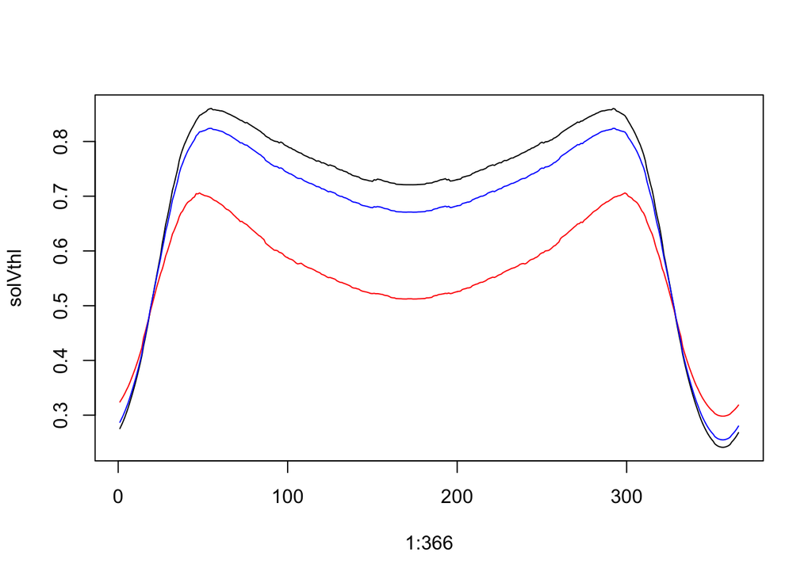

```r
# # How does daily solar radiation compare to topographic heat load
# # correlation max at 0.7 on day 48 (Feb 17) and around day 295 (Oct 21)
# # minimum mid-summer solstice
# head(dlySol)
# head(topo10)
solVthl <- c()
i=1
for (i in 1:366) solVthl[i] <- cor(topo10$thl0,dlySol[,i],use='pair')
plot(1:366,solVthl,type='l')

for (i in 1:366) solVthl[i] <- cor(topo10$thl315,dlySol[,i],use='pair')
lines(1:366,solVthl,col='red')

for (i in 1:366) solVthl[i] <- cor(topo10$thl337,dlySol[,i],use='pair')
lines(1:366,solVthl,col='blue')
```

The following shows scatterplots of pairwise differences matrices for spatial distance vs. each environmental factor, and the accompanying Mantel test. The plots that are commented out are not significant for spatial correlation, and plots that are significant are illustrated. The random string in the box is an identifier to link this code to the results in the manuscript. Site 32 (Kirstenbosch Race Track) is removed from analysis.

As expected, distance from ocean variables are strongly spatially correlated. This raises questions about their interpretation in the models, but they are generally their for the purpose of capturing spatial gradients, so that could be okay. Elevation and slope are also spatially structured, though the scatterplots suggests less concern. Exposure and hillslope positions are not correlated, indicating we did a good job stratifying across the region.

```r
#
# #--------------------------------------------#
# # SPATIAL VARIATION IN TOPOGRAPHIC VARIABLES #
# # a6STycTJVjqM8vRd8V8h                       #
# #--------------------------------------------#
library(ade4)
# check matrices are aligned
all(meta$siteID==topo10$siteID)
```

```
## [1] TRUE
```

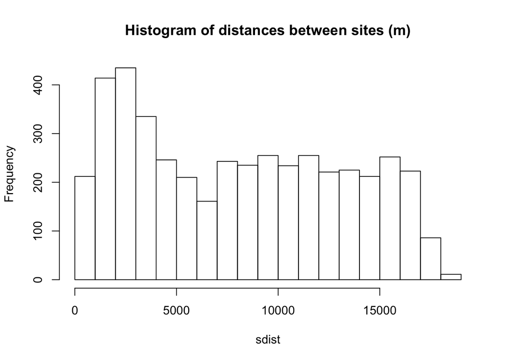

```r
#head(meta)
sdist <- dist(meta[-32,c('UTM.east','UTM.north')])
hist(sdist,main='Histogram of distances between sites (m)')
```

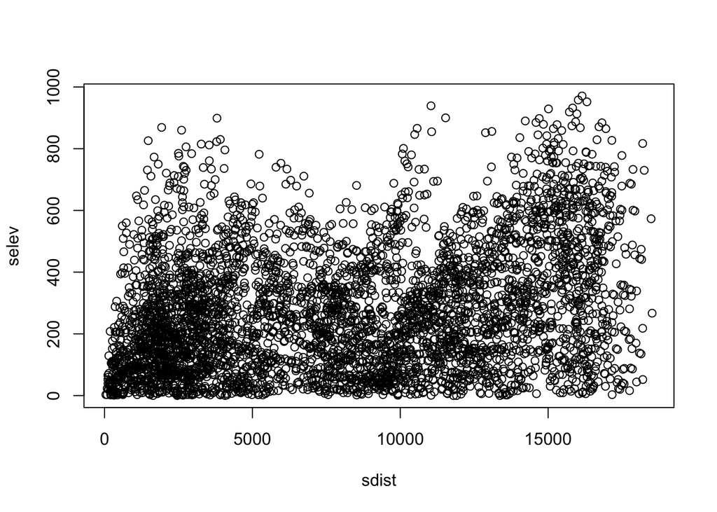

```r
selev <- dist(meta$elevation[-32])
plot(sdist,selev)
```

```r
mantel.rtest(sdist,selev,nrepet=999)
```

```
## Monte-Carlo test
## Observation: 0.2976591
## Call: mantel.rtest(m1 = sdist, m2 = selev, nrepet = 999)
## Based on 999 replicates
## Simulated p-value: 0.001
```

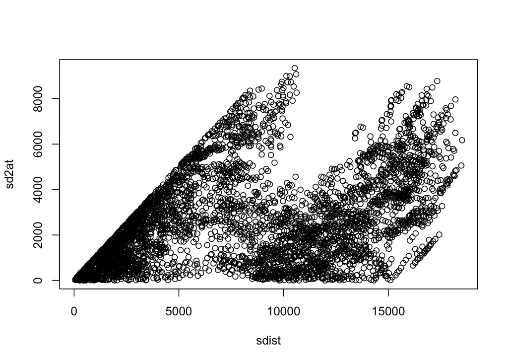

```r
sd2at <- dist(topo10$d2at[-32])
plot(sdist,sd2at)
```

```r
mantel.rtest(sdist,sd2at,nrepet=999)
```

```
## Monte-Carlo test
## Observation: 0.4048515
## Call: mantel.rtest(m1 = sdist, m2 = sd2at, nrepet = 999)
## Based on 999 replicates
## Simulated p-value: 0.001
```

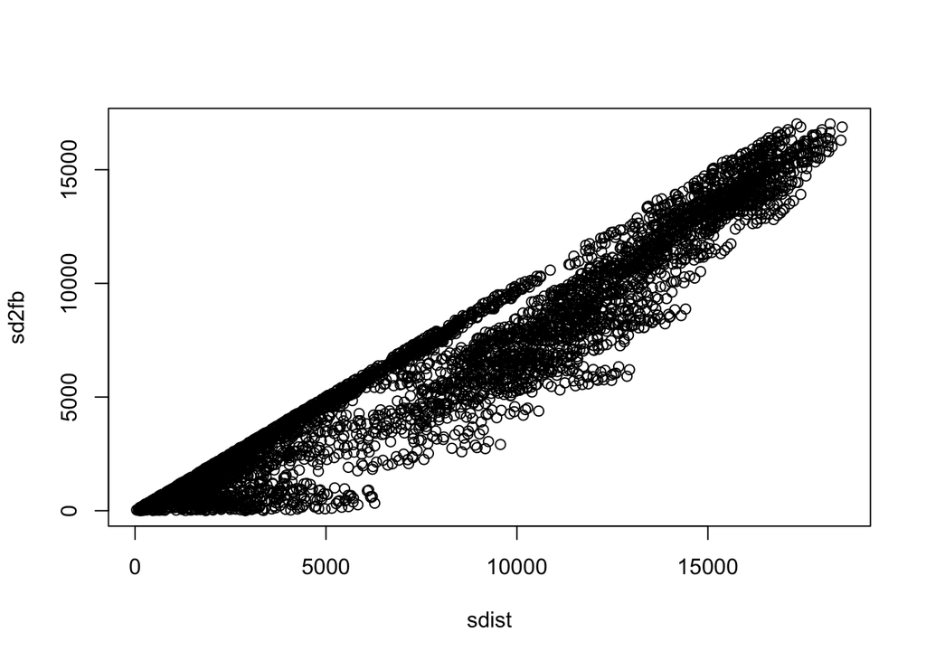

```r
sd2fb <- dist(topo10$d2fb[-32])
plot(sdist,sd2fb)
```

```r
mantel.rtest(sdist,sd2fb,nrepet=999)
```

```
## Monte-Carlo test
## Observation: 0.9611594
## Call: mantel.rtest(m1 = sdist, m2 = sd2fb, nrepet = 999)
## Based on 999 replicates
## Simulated p-value: 0.001
```

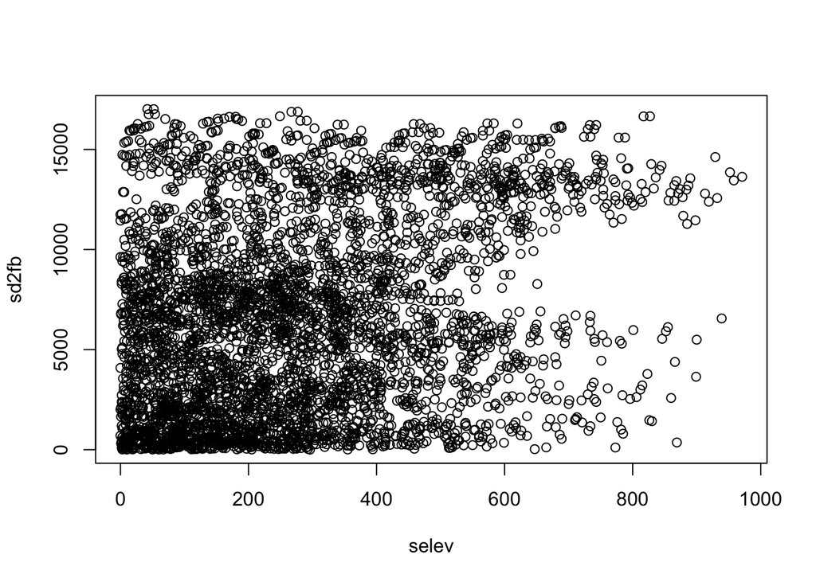

```r
plot(selev,sd2fb)
```

```r
mantel.rtest(selev,sd2fb,nrepet=999)
```

```
## Monte-Carlo test
## Observation: 0.2783594
## Call: mantel.rtest(m1 = selev, m2 = sd2fb, nrepet = 999)
## Based on 999 replicates
## Simulated p-value: 0.001
```

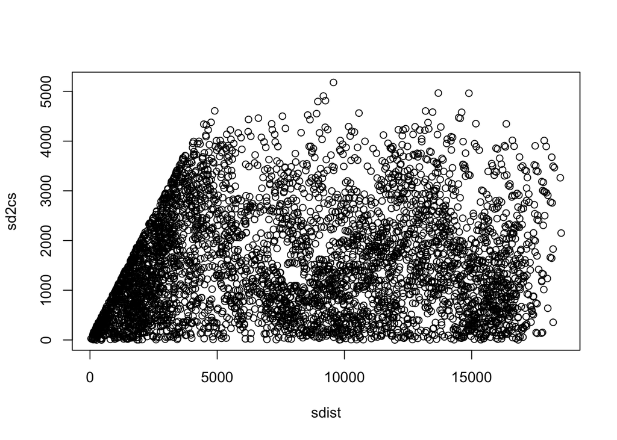

```r
sd2cs <- dist(topo10$d2cs[-32])
plot(sdist,sd2cs)
```

```r
mantel.rtest(sdist,sd2cs,nrepet=999)
```

```
## Monte-Carlo test
## Observation: 0.1044175
## Call: mantel.rtest(m1 = sdist, m2 = sd2cs, nrepet = 999)
## Based on 999 replicates
## Simulated p-value: 0.001
```

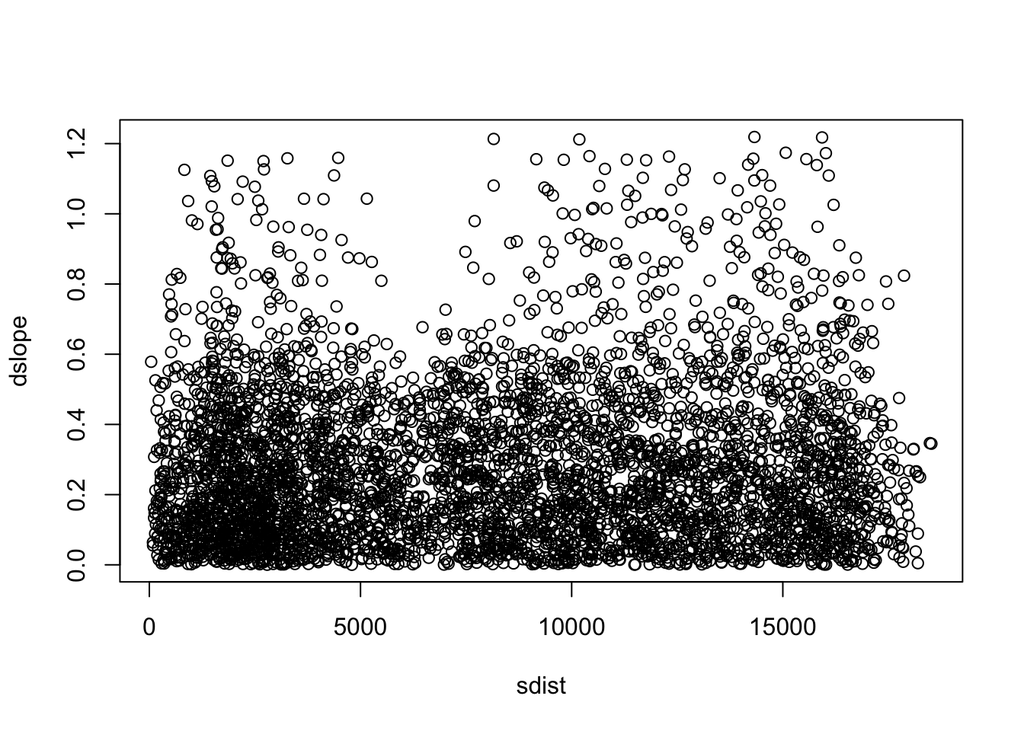

```r
dslope <- dist(topo10$slope[-32])
plot(sdist,dslope)
```

```r
mantel.rtest(sdist,dslope,nrepet=999)
```

```
## Monte-Carlo test
## Observation: 0.0561465
## Call: mantel.rtest(m1 = sdist, m2 = dslope, nrepet = 999)
## Based on 999 replicates
## Simulated p-value: 0.016
```

```r
dtpi50 <- dist(topo10$tpi050[-32])
#plot(sdist,dtpi50)
mantel.rtest(sdist,dtpi50,nrepet=999)
```

```
## Monte-Carlo test
## Observation: 0.02425777
## Call: mantel.rtest(m1 = sdist, m2 = dtpi50, nrepet = 999)
## Based on 999 replicates
## Simulated p-value: 0.181
```

```r
drad080 <- dist(topo10$rad080[-32])
#plot(sdist,drad080)
mantel.rtest(sdist,drad080,nrepet=999)
```

```
## Monte-Carlo test
## Observation: 0.01535659
## Call: mantel.rtest(m1 = sdist, m2 = drad080, nrepet = 999)
## Based on 999 replicates
## Simulated p-value: 0.208
```

```r
dthl <- dist(topo10$thl0[-32])
#plot(sdist,dthl)
mantel.rtest(sdist,dthl,nrepet=999)
```

```
## Monte-Carlo test
## Observation: 0.01342669
## Call: mantel.rtest(m1 = sdist, m2 = dthl, nrepet = 999)
## Based on 999 replicates
## Simulated p-value: 0.229
```

```r
# #-------------------------------------------------#
# # MAKE 3 CHAR DAYS VAR, for dlySol variable names #
# #-------------------------------------------------#
days <- as.character(1:366)
days[nchar(days)==1] <- paste('00',days[nchar(days)==1],sep='')
days[nchar(days)==2] <- paste('0',days[nchar(days)==2],sep='')
```

```r
#-------------------------------#
# DAILY WEATHER MODELS          #
# OHkNt68RXvbTk4jHfczb          #
#-------------------------------#

# Run through daily models testing all combinations of elevation, radiation, hillslope, and regional position terms
radterm <- c('dsol','rad080','rad172','rad355','thl315','thl337','thl0')
hillterm <- c('tpi050','tpi125','tpi250','tpi500','plow050','plow125','plow250','plow500')
regterm <- c('d2fb','d2at','d2cs')
slterm <- 'slope'
nModels <- length(radterm)*length(hillterm)*length(regterm)

modterms <- matrix(NA,nModels,5)
modnums <- matrix(NA,nModels,5)
n <- 0
for (i in 1:length(radterm)) for (j in 1:length(hillterm)) for (k in 1:length(regterm)) {
    n <- n+1
    modterms[n,] <- c('elevation',radterm[i],hillterm[j],regterm[k],slterm)
    modnums[n,] <- c(1,i,j,k,1)
}

## running all possible models on daily basis for six dependent parameters: Tmin, Tmax, T06, T14, RHsat.hrs, VPmax
RSQelev <- list() # r-squared, elevation only model
MSEelev <- list() # mean square error, elevation only model
RSQm5x <- list() # highest r-squared, 5 term model
MSEm5x <- list() # mean square error for max r-squared 5 term model
BFm5x <- list() # best-fit model: number from 1:120 indicating which had highest r-squared
RSQm5 <- list() # matrix of 120 r-squared for all 5 term models
MSEm5 <- list() # matrix of 120 mean square errors for all 5 term models
dAICx <- list() # delta AIC from drop1 function for bf model
rSlpx <- list() # regression slopes from bg model

vars <- c('Tmin','Tmax','T06','T14','RHsat.hrs','VPmax')
for (v in 1:length(vars)) {
    RSQm5[[v]] <- matrix(NA,366,ncol=nModels)
    MSEm5[[v]] <- matrix(NA,366,ncol=nModels)
    RSQelev[[v]] <- rep(NA,366)
    MSEelev[[v]] <- rep(NA,366)
    RSQm5x[[v]] <- rep(NA,366)
    MSEm5x[[v]] <- rep(NA,366)
    BFm5x[[v]] <- rep(NA,366)
    dAICx[[v]] <- matrix(NA,366,5)
    rSlpx[[v]] <- matrix(NA,366,5)
}
```

```r
v <- 1
for (v in 1:length(vars)) {
    d <- 1
    for (d in 1:366) {
        #print(c(v,d))
        dd <- subset(dw,dw$doy==d)
        dd <- dd[match(dd$siteID,meta$siteID),]
        dd$yvar <- dd[,vars[v]]
        dd$yvar[meta$use4Analyses==0] <- NA
        topo10$dsol <- dlySol[,paste('rad_tot_',days[d],sep='')]

        #  Base model with elevation only
        fit1 <- lm(dd$yvar~elevation,data=topo10)
        RSQelev[[v]][d] <- summary(fit1)$r.sq
        MSEelev[[v]][d] <- sd(fit1$residuals,na.rm=T)

        # run all 5 parameter models
        n <- 0
        i=1;j=1;k=1
        for (i in 1:length(radterm)) for (j in 1:length(hillterm)) for (k in 1:length(regterm)) {
            n <- n+1
            #print(c(d,i,j,k,n))

            fit2 <- lm(dd$yvar~topo10[,'elevation']+topo10[,radterm[i]]+topo10[,hillterm[j]]+topo10[,regterm[k]]+topo10[,slterm])
            RSQm5[[v]][d,n] <- summary(fit2)$r.sq
            MSEm5[[v]][d,n] <- sd(fit2$residuals,na.rm=T)
#             if (n==1) {
#                 mrs <- summary(fit2)$r.sq
#                 d1 <- coefficients(drop1(fit2))
#                 dAICx[[v]][d,] <- drop1(fit2)$AIC[-1]
#             } else {
#                 if (summary(fit2)$r.sq > mrs) {
#                     mrs <- summary(fit2)$r.sq
#                     d1 <- coefficients(drop1(fit2))
#                     dAICx[[v]][d,] <- drop1(fit2)$AIC[-1]
#                 }
#             }
        }
        ## now extract rsq and mse for the best model, and record id # of best model
        BFm5x[[v]][d] <- which.max(RSQm5[[v]][d,])
        RSQm5x[[v]][d] <- RSQm5[[v]][d,BFm5x[[v]][d]]
        MSEm5x[[v]][d] <- MSEm5[[v]][d,BFm5x[[v]][d]]

        # rerun best model to extract dAIC values
        i <- modnums[BFm5x[[v]][d],2]
        j <- modnums[BFm5x[[v]][d],3]
        k <- modnums[BFm5x[[v]][d],4]
        fit2 <- lm(dd$yvar~topo10[,'elevation']+topo10[,radterm[i]]+topo10[,hillterm[j]]+topo10[,regterm[k]]+topo10[,slterm])
        d1 <- drop1(fit2)$AIC
        dAICx[[v]][d,] <- d1[-1]-d1[1]
        rSlpx[[v]][d,] <- fit2$coefficients[-1]
    }
}

saveRDS(list(RSQelev,MSEelev,RSQm5,MSEm5,RSQm5x,MSEm5x,BFm5x,dAICx,rSlpx,modterms,modnums),file='data/Rdata/M5out.Rdata')
```